# The optogenetic revolution is transforming neuroscience”. Discuss

L.-Y. M.

2024-03-19

# Preface

This essay is my coursework for the module “Foundamental of Neuroscience” at the University of Sheffield. The essay is about 2000 words long. You can find the PDF version of the essay [here](https://github.com/Lingyu-Meng/Optogenetic/blob/a6dabb53103fe1cba0ccb60034e57c8e4b967cd4/Optogenetic.pdf). I got 72% for this essay, which is a first-class mark in UK.

This essay is licensed under the [Creative Commons Attribution-NonCommercial-ShareAlike 4.0 International License](http://creativecommons.org/licenses/by-nc-sa/4.0/).

# Main body

“And God said, Let there be light: and there was light.” (Genesis, 1:3)

Imaging a switch held by alien, which can control peoples’ mind or at least can control peoples’ behaviours. Once the switch is on, individuals will attack those in front of them, regardless of their relationship. For human, that is unreality described by sci-fin writer; for mice that is reality demonstrated by scientist. Gene edited male mice will strike their partner during sexual activity once the intensity of light directed at their implanted fibre increase<sup>1</sup> . The tool makes it achievable is called optogenetics.

Optogenetics literally sheds a light on neuron to shed light on principle of neuroscience. Biologist found a light-gated cation channel, Channelrhodopsin-2 (ChR2), in 2003<sup>2</sup>. Then some scientists came out an idea about express ChR<sup>2</sup> in neuron<sup>3,4</sup>. By control light, active potential can be made arbitrarily in neuron which expressed ChR2. To express opsins into the brain of various animal, lentiviruses and adenoassociated virus are used classically, and cellular specificity can be obtained by combination with transgenic technique or simply by inject virus to targeting area. The optogenetics awarded the “Method of the Year” in 2010<sup>5</sup>, and an explosion of papers happened (Figure 1). There are numerous optogenetic tools developed during this period. Now people can depolarise<sup>4</sup> or hyperpolarise<sup>6</sup> neurons on cellular level resolution<sup>7</sup> in vivo by different wavelength light8 . This advancement has turned thousands of “dream experiment” into reality.

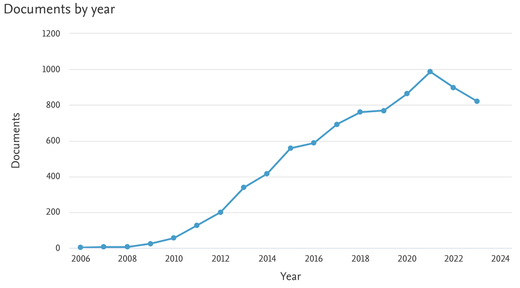

Figure 1. Number of articles published per year from 2006 to 2023 that included the words “optogenetic” in the title, abstract, or keywords<sup>9</sup>. Data from Scopus, 5 November 2023.

One of the most cited optogenetic research article directly tests the cellular mechanism of gamma oscillation<sup>10</sup>. Cardin *et al.* selectively activate fast-spiking (FS) interneurons and regular spiking (RS) single units respectively. The former is inhibitory neuron, while the latter is excitatory. They found that light-activated (40 Hz) FS spikes can amplify the power rate of local field potential (LFP) in gamma band, but not RS. Meanwhile, lower frequency light-activated (8 Hz) RS spikes can amplify the relative LFP power at 8 Hz, but not FS. This double dissociation directly and strongly supports the fast-spiking-gamma hypothesis<sup>11</sup>, and successfully demonstrated the causal role of a specific type cell in the generation of neural oscillation. This experiment can nether be implemented through brain electric stimulation as it hasn’t cellular type specificity, nor be achieved by pharmacy as it hasn’t frequency specificity.

Another significant aspect of optogenetics is it can also activate layer-specific neurons. An example of this is the study carried out by Chan *et al.* in brain-wide functional influence of different layer of primary motor cortex (M1)<sup>12</sup>. They stimulated neurons in layers 2/3 (L2/3), L4, L5 and L6 respectively and recording the functional magnetic resonance imaging (fMRI) signal simultaneously. This study exhaustively shows how neurons from different layers affect each other in ipsilateral and contralateral cortex and compare LFP and blood oxygen level dependent (BOLD) signal in the circumstance of which neuron are firing is known.

The most widespread research used optogenetics is which one can directly manipulate behaviour by activated neural ensemble. One of those research is manipulating attack behaviour of mice which is mentioned at the beginning of the essay<sup>1</sup> . A subset of the ventromedial hypothalamus neurons has been found modulating social behaviour of male mice. It is activated at medial level during close investigation and mounting whilst at hight level during attack. Recently, Marshel et al. use optogenetic technique activated neural ensemble in visual cortex of mice and evoked corresponding behaviour<sup>13</sup>. They trained mice to response drifting horizontal (distractor) or vertical (target) gratings in a Go/No-Go task. Those mice correctly response for photostimulation target vertical orientation-tuned ensembles but not random ensembles or the horizontal. This is a great improve upon reading and writing neural activity and shown us a way to more precisely investigate visual, even delusions in cellular level.

Even though optogenetics has shown a significant influence on neuroscience and achieved numerous breakthroughs on principle of neuroscience, people who do not focus on animal research may overlook the potential of optogenetics. Opsin as photosensitive protein has been considered as a promising way to help blind regaining vision since it was introduced to public and implement in vivo<sup>4</sup> . Now this application are verified in human<sup>14</sup> and just completed phase 2 clinical trial<sup>15</sup>. They are administered by injecting an AVV vectors into the eye and combined with light stimulation through engineered goggles. To activate the corresponding retinal ganglion cells, goggles are used to detect local changes in light intensity and project the corresponding pulses of light onto the retina in real time. Despite depended on wearable device, this therapy has successfully partially restored functionality affected by retinitis pigmentosa. It is also concerned of other translation medical use such as treat epilepsy<sup>16</sup> , deafness<sup>17</sup> and Parkinson’s Disease<sup>18</sup>.

The previous section has shown how optogenetics influenced neuroscience, but it is not the master key without any side effect. Some people maintain that the trends of pompousness in academia<sup>19</sup> make every study seem like a revolution. Therefore, it is necessary to know the limitation of optogenetics for evaluate how it is transforming neuroscience and to what extent it can be call as a revolution. Firstly, as a tool of basic research in neuroscience, optogenetics has several limitations that are difficult to be overcome. One common limitation of optogenetics could be the difference between the opt-activated neural activities and spontaneous neural activities.

After opto-activated inhibition, the probability spiking evoked by synapses may increase<sup>20</sup>. Depending on the type of virus, the lifespan of transfected neuron could be as short as one week<sup>21</sup>. Due to the foreign body response, the expiry time of optogenetic fibre is relatively short; only recently people can use optostimulation to evoke neural potential as long as 6 months<sup>22</sup>. Despite the probability of prolonging lifespan, frequently replacing the optical fibre or intermittently suspending targeting the same brain region is inevitable.

Secondly, the promising value of treatment may not be fully realised. Except the intraocular injection<sup>14</sup>, the treatment for most neural disease required high-resolution neural manipulation. Current technology achieves it via combination optogenetics with transgenic techniques, which is hardly bypass the ethic controversy in the foreseeable future, if used on human. Even if we could, the cost, in terms of time, would be too high. Research on monkeys with optogenetics is also rare for the same reason.

Thirdly, the extent to which optogenetics has helped us to understand the brain remains unclear. Explaining negative result poses a big challenge. This may be due to the complexity of the neural circuit, insufficient opsin expression, or the irrelevancy of targeted neuron. Optogenetics encourages the pursuit of significant positive results within the highly complex system, the brain, so it makes the drawer biases much serious in neurobiology. In contrary, negative result in lesion research may inspire our understand about the function of region<sup>23</sup>. Even positive results can be tricky too. As previously discussed, the optostimulation couldn’t exist for long time, therefore is it uncertain about whether our positive result is solid as it is proved acute manipulation and chronic change of neural circuit may different<sup>24</sup>. Otchy *et al.* found that trained mice can keep their performance on the behaviour task after motor cortex lesion and 5-10 days recovery period. However, they exhibited a significant deficit when same region was disrupted by optogenetic stimulation. Therefore, it raises the question of whether those amazing result of optogenetics can be sustained and, if not, what these research finding truly told us about the brain.

Obviously, it is not necessary to address every question to qualified as a science revolution. According to Kuhn, a scientific revolution is a “non-cumulative developmental episodes in which an older paradigm is replaced in whole or in part by an incompatible new one” (p. 92)<sup>25</sup>. Kuhn’s term “paradigm” refers to the shared commitments, including methodological ones, of a scientific group and can be hierarchical, thereby rendering scientific revolutions relative as well<sup>25,26</sup>. Moreover, Kuhn arguers that “paradigm changes do cause scientists to see the world of their research- engagement differently” (p. 111)<sup>25</sup>.

The emergence of optogenetics has undeniably transformed the practices in neurobiology. It is commonly employed to verify the neural projections and upstream/downstream relationships in research<sup>27,28</sup>. Some even consider it the golden standard for circuit manipulation<sup>29–31</sup>. However, from Kuhn’s perspective, optogenetics does not qualify as a scientific revolution. Unlike the shift from Newton to Einstein, the development of optogenetics didn’t alter the fundamental understanding of the brain or neurons. Before the advent of optogenetics, we were already aware that the influx/outflux of ions through protein-made channels dictates neuron spiking, which in turn determines the signal of neural circuits and neural networks. Boyden’s pursuit of a suitable opsin, which helped him noticed and gained ChR2, stemmed from this pre-existing knowledge<sup>32</sup>. Whilst optogenetics introduced a new approach for asking and answering research question, it remains completely compatible with our previous paradigm. Therefore, regrettably, nether incommensurable new paradigm was established, nor the view of world changed.

Nevertheless, Kuhn’s definition of scientific revolution is almost primarily based on physics in the last century and earlier. The explosion of molecular biology might not align with Kuhn’s earlier theory. Baird realised how the development of instrument affect science in analytic chemistry<sup>33</sup>. Bickle believes neuroscience shares the same characteristics and refers to optogenetics as a case of neuroscientific revolution<sup>34</sup>. To avoid arguing in a circle, the following will discuss how previous tool developments has affected the neuroscience and compare them to optogenetics.

During earlier period, the improvement in understanding the brain followed Kuhn’s description of a revolution. An early paradigm shift in neuroscience concerns the structure of the basic nerve unit. Camillo Golgi supported “reticular theory”, suggesting that “each nerve cell was connected to its neighbours by protoplasmic links” (p. 5), whereas Santiago Ramón y Cajal believed in the “neuron doctrine”, proposing that “nerve cell are discrete entities” (p. 5)<sup>35</sup>. This argument was resolved by directly observing synapses using an electrical microscope. Subsequently, electron microscopy acted as the primary method for researching neuronal ultrastructure. Similarly, Semon believed memory is encoded by “engram” cell, whilst Lashley, after failing to find it, augured that memory encoded in whole brain<sup>36</sup>. This question was addressed by optogenetics through activation of fear memory<sup>37</sup> and the creation of a false memory<sup>38</sup>.

Given the criticisms aimed at neuroscience tools, there have been multiple questions raised about whether scientists possess sufficient tools. Lazebnik attempted to repair a radio in a biologist’s manner, dissecting and comparing, lesioning, and resorting to Shotgun sequencing<sup>39</sup> . He suggested that a biologist could mend a radio if all its components, connections, and the consequences of their removal were thoroughly examined and if the radio hasn’t tuneable components. The difficulty encountered in this process was attributed to the absence of such language as a flaw in biological research. However, the inefficiency could also be explained by the lack of tool development, especially in building dynamically created tools using acquired knowledge. Furthermore, Jonas employed neuroscience methods, encompassing lesion studies, connectomic analysis, spiking, LFP, Granger causality, and more, to explore the functioning of processors (MOS 6502)<sup>40</sup>. His conclusion was more pessimistic, suggesting that even with all the processor data available, current neuroscience methods are unable to decipher how the processor works while playing a video game. His findings suggest the necessity for innovative and advanced tools to decode intricate non-linear systems, indicating the urgency and significance of tool development in neuroscience.

Overall, if the advancements in neuroscience techniques and tools, such as staining, neuroimaging, neuromanipulation, and electrophysiology, are deemed as revolutionary, then optogenetics could reasonably be considered a part of this revolution. However, if these advancements are not regarded as revolutionary, it becomes challenging to identify any significant revolution within the field of neuroscience over the last two decades.

# Reference

1. Lee H. et al. Scalable control of mounting and attack by esr1+ neurons in the ventromedial hypothalamus. Nature 509, 627–632 (2014).
2. Nagel G. et al. Channelrhodopsin-2, a directly light-gated cation-selective membrane channel. Proc. Natl. Acad. Sci. 100, 13940–13945 (2003).
3. Boyden E. S., Zhang F., Bamberg E., Nagel G. & Deisseroth K. Millisecond-timescale, genetically targeted optical control of neural activity. Nat Neurosci 8, 1263–1268 (2005).
4. Bi A. et al. Ectopic expression of a microbial-type rhodopsin restores visual responses in mice with photoreceptor degeneration. Neuron 50, 23–33 (2006).
5. Method of the year 2010. Nat. Methods 8, 1–1 (2011).
6. Gradinaru V., Thompson K. R. & Deisseroth K. ENpHR: A natronomonas halorhodopsin enhanced for optogenetic applications. Brain Cell Bio 36, 129–139 (2008).
7. Wu F. et al. Monolithically integrated μLEDs on silicon neural probes for high-resolution optogenetic studies in behaving animals. Neuron 88, 1136–1148 (2015).
8. Prigge M. et al. Color-tuned channelrhodopsins for multiwavelength optogenetics. J. Biol. Chem. 287, 31804–31812 (2012).
9. Scopus - analyze search results. https://www.scopus.com/term/analyzer.uri?sort=plf-f&src=s&sid=8d33fc6cffe579710b4d9da92ae6a519&sot=a&sdt=a&sl=26&s=TITLE-ABS-KEY%28optogenetic%29&origin=resultslist&count=10&analyzeResults=Analyze+results.
10. Cardin J. A. et al. Driving fast-spiking cells induces gamma rhythm and controls sensory responses. Nature 459, 663–667 (2009).
11. Hasenstaub A. et al. Inhibitory postsynaptic potentials carry synchronized frequency information in active cortical networks. Neuron 47, 423–435 (2005).
12. Chan R. W. et al. Distinct local and brain-wide networks are activated by optogenetic stimulation of neurons specific to each layer of motor cortex. NeuroImage 263, 119640 (2022).
13. Marshel J. H. et al. Cortical layer–specific critical dynamics triggering perception. Science 365, eaaw5202 (2019).
14. Sahel J.-A. et al. Partial recovery of visual function in a blind patient after optogenetic therapy. Nat. Med. 27, 1223–1229 (2021).
15. A phase 2b randomized, double-masked, sham-controlled, study to evaluate the efficacy and safety of intravitreal injection of MCO-010 optogenetic therapy in adults with retinitis pigmentosa [RESTORE]. https://clinicaltrials.gov/study/NCT04945772 (2023).
16. Walker M. C. & Kullmann D. M. Optogenetic and chemogenetic therapies for epilepsy. Neuropharmacology 168, 107751 (2020).
17. Wrobel C. et al. Optogenetic stimulation of cochlear neurons activates the auditory pathway and restores auditory-driven behavior in deaf adult gerbils. Sci. Transl. Med. 10, eaao0540 (2018).
18. Valverde S. et al. Deep brain stimulation-guided optogenetic rescue of parkinsonian symptoms. Nat. Commun. 11, 2388 (2020).
19. Vinkers C. H., Tijdink J. K. & Otte W. M. Use of positive and negative words in scientific PubMed abstracts between 1974 and 2014: Retrospective analysis. BMJ 351, h6467 (2015).
20. Raimondo J. V., Kay L., Ellender T. J. & Akerman C. J. Optogenetic silencing strategies differ in their effects on inhibitory synaptic transmission. Nat. Neurosci. 15, 1102–1104 (2012).
21. Wickersham I. R. et al. Monosynaptic restriction of transsynaptic tracing from single, genetically targeted neurons. Neuron 53, 639–647 (2007). P a g e | 5
22. Park S. et al. Adaptive and multifunctional hydrogel hybrid probes for long-term sensing and modulation of neural activity. Nat. Commun. 12, 3435 (2021).
23. Rudebeck P. H., Saunders R. C., Prescott A. T., Chau L. S. & Murray E. A. Prefrontal mechanisms of behavioral flexibility, emotion regulation and value updating. Nat. Neurosci. 16, 1140–1145 (2013).
24. Otchy T. M. et al. Acute off-target effects of neural circuit manipulations. Nature 528, 358– 363 (2015).
25. Kuhn, T. S. & Hacking, I. The structure of scientific revolutions. (The University of Chicago Press, 2012).
26. Kuhn, T. S. Second thoughts on paradigms. in The essential tension: Selected studies in scientific tradition and change 293–319 (University of Chicago Press, 1978).
27. Liu, Y. et al. Molecular and cellular mechanisms of the first social relationship: A conserved role of 5-HT from mice to monkeys, upstream of oxytocin. Neuron S0896627323001149 (2023) doi:10.1016/j.neuron.2023.02.010.
28. Padilla-Coreano, N. et al. Cortical ensembles orchestrate social competition through hypothalamic outputs. Nature 603, 667–671 (2022).
29. Montagni E., Resta F., Mascaro A. L. A. & Pavone F. S. Optogenetics in brain research: From a strategy to investigate physiological function to a therapeutic tool. Photonics 6, 92 (2019).
30. Klapper S. D. et al. On-demand optogenetic activation of human stem-cell-derived neurons. Sci. Rep. 7, 14450 (2017).
31. McLean D. L. Optogenetics: Illuminating sources of locomotor drive. Curr. Biol. 23, R441– R443 (2013).
32. Boyden E. S. A history of optogenetics: the development of tools for controlling brain circuits with light. F1000 Biol Rep 3, (2011).
33. Baird D. Thing knowledge: A philosophy of scientific instruments. (University of California Press, 2004).
34. Bickle J. Revolutions in neuroscience: Tool development. Frontiers in Systems Neuroscience 10, (2016).
35. Purves, D., Mooney, R. D. & Platt, M. L. Neuroscience. (Sinauer Associates, 2012).
36. Lashley K. S. Brain mechanisms and intelligence: A quantitative study of injuries to the brain. xi, 186 (University of Chicago Press, 1929). doi:10.1037/10017-000.
37. Liu X. et al. Optogenetic stimulation of a hippocampal engram activates fear memory recall. Nature 484, 381–385 (2012).
38. Ramirez S. et al. Creating a false memory in the hippocampus. Science 341, 387–391 (2013).
39. Lazebnik, Y. Can a biologist fix a radio?—or, what I learned while studying apoptosis. Cancer Cell 2, 179–182 (2002).
40. Jonas E. & Kording K. P. Could a neuroscientist understand a microprocessor? Plos Comput. Biol. 13, e1005268 (2017).